# Teste Técnico - Credits Brasil

Renan Santos

2023-10-27

# 1 Contextualização

O objetivo deste documento é descrever o processo de tratamento e análise de dados a fim de abordar as questões apresentadas no teste técnico. As questões são as seguintes:

1. Quais regiões com mais clientes fidelizados?
2. Quais regiões com menor média na nota de consumo?
3. Qual melhor mês para fazer uma campanha de aniversário para o público fidelizado?
4. Qual percentual de fidelização do público da região Sul e Sudeste?
5. Queremos lançar um novo produto para o público que possui nota de consumo abaixo de 45, porém são fidelizados. Quais 5 estados devemos selecionar para o lançamento?

# 2 Carregamento de bibliotecas

Carregamento dos pacotes da biblioteca **Tidyverse**, utilizados na transformação e análise dos dados, bem como do pacote **rmarkdown**, utilizado em algumas visualizações deste documento.

```r
library("tidyverse")
library("rmarkdown")
```

# 3 Carregamento da base de dados

```r
df <- readxl::read_xlsx(path = "Teste Excel - Estágio de Dados.xlsx", sheet = "Base de Dados")
```

Carregamento da planilha Excel contendo a base de dados na váriavel `df`.

# 4 Visualização da base de dados

Visualização dos nomes das colunas e tipos de dados com o método `glimpse`.

```r
glimpse(df)
```

```
## Rows: 1,027
## Columns: 7
## $ `Cod cliente`     <dbl> 161, 421, 502, 670, 722, 788, 999, 34, 240, 278, 451…
## $ telefone          <dbl> 72722835, NA, 21431998, 88860560, 66592537, 74101812…
## $ `e-mail`          <chr> "72722835@email.com", "63898077@email.com", "2143199…
## $ UF                <chr> "SP", "SP", "PA", "DF", "SC", "SE", "AL", "RR", "SP"…
## $ `Nota de consumo` <dbl> 0, 0, 0, 0, 0, 0, 0, 1, 1, 1, 1, 1, 1, 1, 1, 1, 1, 1…
## $ Aniversário       <chr> "Novembro", "Fevereiro", "Março", "Abril", "Março", …
## $ Fidelidade        <chr> "Sim", "Não", "Não", "Nâo", "Não", "Não", "Não", "Si…
```

Visualização em páginas de toda a base de dados com o método `paged_table`

```r
paged_table(df)
```

| Cod cliente | telefone | e-mail | UF | Nota de consumo | Aniversário | Fidelidade |
| --- | --- | --- | --- | --- | --- | --- |
| 161 | 72722835 | 72722835@email.com | SP | 0 | Novembro | Sim |
| 421 | NA | 63898077@email.com | SP | 0 | Fevereiro | Não |
| 502 | 21431998 | 21431998@email.com | PA | 0 | Março | Não |
| 670 | 88860560 | 88860560@email.com | DF | 0 | Abril | Nâo |
| 722 | 66592537 | 66592537@email.com | SC | 0 | Março | Não |
| 788 | 74101812 | 74101812@email.com | SE | 0 | Novembro | Não |
| 999 | 76710810 | 76710810@email.com | AL | 0 | Maio | Não |
| 34 | 59941006 | 59941006@email.com | RR | 1 | Maio | Sim |
| 240 | 98341146 | 98341146@email.com | SP | 1 | Janeiro | Não |
| 278 | NA | 37750108@email.com | RR | 1 | Janeiro | Não |

[output cut: 1017 more lines]

É possível visualizar as seguintes observações:

- As colunas `Cod Cliente`, `telefone` e `Nota de consumo` representam números **inteiros**, no entanto, foram carregadas com o tipo **Double**.
- A base de dados pode conter alguns valores ausentes e duplicados.
- A coluna `Aniversário` não está ordenada por mês, o que impede a ordenação dos dados de acordo com a sequência dos meses do ano.
- Seria interessante se a base de dados contivesse uma coluna que representasse as regiões Norte, Nordeste, Centro-Oeste, Sudeste e Sul, a fim de reposder algumas questões.

# 5 Transformação da base de dados

Nesta etapa, serão realizadas algumas transformações na base de dados com o objetivo de abordar as observações feitas anteriormente.

## 5.1 Alteração de tipo de dados

Alteração do tipo de dado das colunas `Cod cliente`, `telefone` e `Nota de consumo` para o tipo **Integer**.

```r
df$`Cod cliente` <- as.integer(df$`Cod cliente`)
df$telefone <- as.integer(df$telefone)
df$`Nota de consumo` <- as.integer(df$`Nota de consumo`)
```

## 5.2 Valores ausentes e duplicados

```r
df <- df %>% complete()
```

## 5.3 Ordenação de meses

O código abaixo estabelece uma ordenação para a coluna `Aniversário` com base na sequência de meses do ano. Caso isso não seja feito, o R considerará uma ordenação alfabética ao listar os meses do ano.

```r
df$Aniversário <- ordered(df$Aniversário,
                          levels = c("Janeiro","Fevereiro","Março",
                                     "Abril","Maio","Junho",
                                     "Julho","Agosto", "Setembro",
                                     "Outubro","Novembro","Dezembro"))
```

## 5.4 Nova coluna Região

Criação da coluna `Região` para representar a região geográfica dos clientes, sendo Norte, Nordeste, Centro-Oeste, Sudeste ou Sul.

```r
df <- df %>%
  mutate("Região" = case_when(UF == "SP" ~ "Sudeste",
                              UF == "PA" ~ "Norte",
                              UF == "DF" ~ "Centro-Oeste",
                              UF == "SC" ~ "Sul",
                              UF == "SE" ~ "Nordeste",
                              UF == "AL" ~ "Nordeste",
                              UF == "RR" ~ "Norte",
                              UF == "MG" ~ "Sudeste",
                              UF == "RJ" ~ "Sudeste",
                              UF == "RS" ~ "Sul",
                              UF == "PR" ~ "Sul",
                              UF == "MS" ~ "Centro-Oeste",
                              UF == "AM" ~ "Norte",
                              UF == "MT" ~ "Centro-Oeste",
                              UF == "AC" ~ "Norte",
                              UF == "MA" ~ "Nordeste"))
```

## 5.5 Visualização de dados tratados

```r
glimpse(df)
```

```
## Rows: 1,027
## Columns: 8
## $ `Cod cliente`     <int> 161, 421, 502, 670, 722, 788, 999, 34, 240, 278, 451…
## $ telefone          <int> 72722835, NA, 21431998, 88860560, 66592537, 74101812…
## $ `e-mail`          <chr> "72722835@email.com", "63898077@email.com", "2143199…
## $ UF                <chr> "SP", "SP", "PA", "DF", "SC", "SE", "AL", "RR", "SP"…
## $ `Nota de consumo` <int> 0, 0, 0, 0, 0, 0, 0, 1, 1, 1, 1, 1, 1, 1, 1, 1, 1, 1…
## $ Aniversário       <ord> Novembro, Fevereiro, Março, Abril, Março, Novembro, …
## $ Fidelidade        <chr> "Sim", "Não", "Não", "Nâo", "Não", "Não", "Não", "Si…
## $ Região            <chr> "Sudeste", "Sudeste", "Norte", "Centro-Oeste", "Sul"…
```

```r
paged_table(df)
```

| Cod cliente | telefone | e-mail | UF | Nota de consumo | Aniversário | Fidelidade | Região |
| --- | --- | --- | --- | --- | --- | --- | --- |
| 161 | 72722835 | 72722835@email.com | SP | 0 | Novembro | Sim | Sudeste |
| 421 | NA | 63898077@email.com | SP | 0 | Fevereiro | Não | Sudeste |
| 502 | 21431998 | 21431998@email.com | PA | 0 | Março | Não | Norte |
| 670 | 88860560 | 88860560@email.com | DF | 0 | Abril | Nâo | Centro-Oeste |
| 722 | 66592537 | 66592537@email.com | SC | 0 | Março | Não | Sul |
| 788 | 74101812 | 74101812@email.com | SE | 0 | Novembro | Não | Nordeste |
| 999 | 76710810 | 76710810@email.com | AL | 0 | Maio | Não | Nordeste |
| 34 | 59941006 | 59941006@email.com | RR | 1 | Maio | Sim | Norte |
| 240 | 98341146 | 98341146@email.com | SP | 1 | Janeiro | Não | Sudeste |
| 278 | NA | 37750108@email.com | RR | 1 | Janeiro | Não | Norte |

[output cut: 1017 more lines]

É possível observar que todas as modificações foram realizadas com sucesso, o que tornará a próxima fase de análise dos dados mais facilitada.

# 6 Análise e visualização de dados

Nesta etapa será realizada uma análise dos dados com o intuito de responder a todas as questões.

## 6.1 Quantidade de clientes fidelizados por região

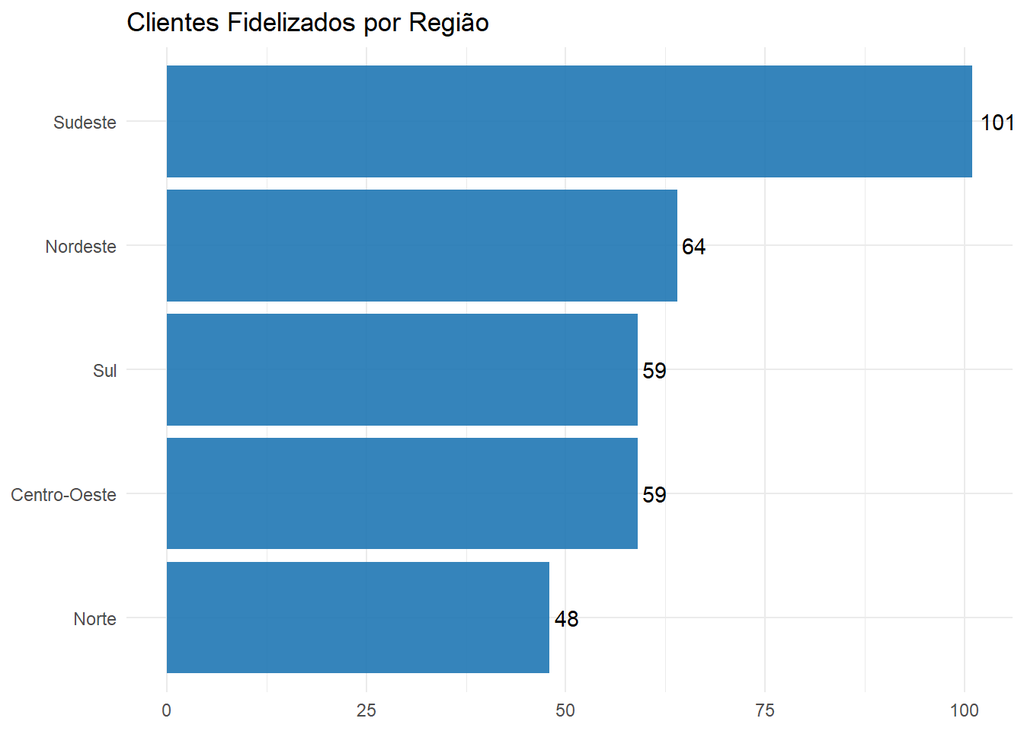

```r
df %>%
  filter(Fidelidade == "Sim") %>%
  group_by(Região) %>%
  summarise('Qtd Clientes' = n()) %>%
  ggplot(aes(reorder(Região, +`Qtd Clientes`), `Qtd Clientes`)) +
  geom_col(fill = "#1f77b4", alpha = 0.9) +
  geom_text(aes(label = `Qtd Clientes`), hjust = -0.2) +
  coord_flip() +
  labs(title = "Clientes Fidelizados por Região", y=NULL, x=NULL) +
  theme_minimal()
```

O gráfico acima representa a quantidade de clientes fidelizados por região. É notável que o Sudeste possui um número significativamente maior de clientes fidelizados, estando bem à frente da maioria dos outros estados.

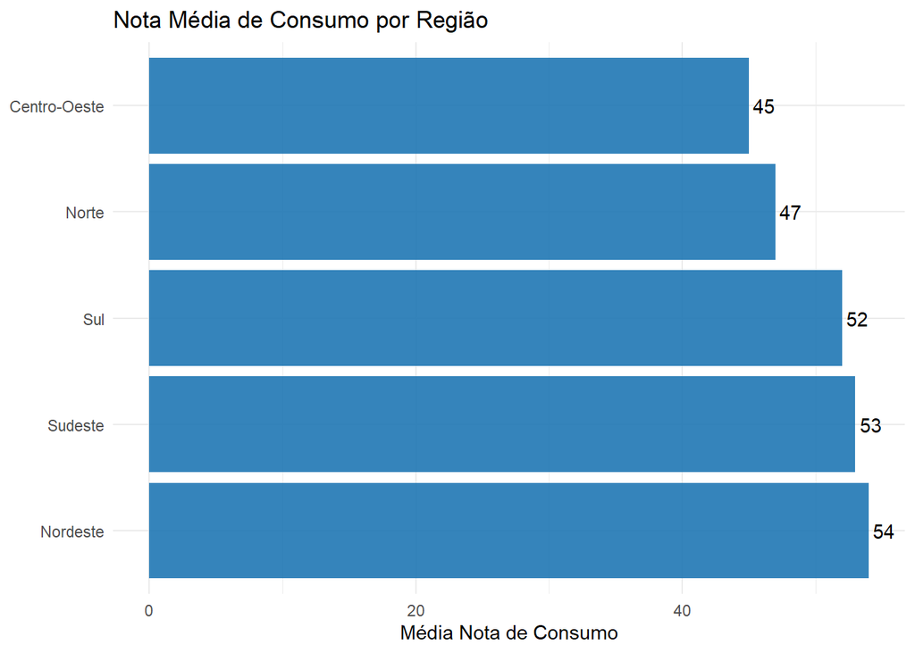

```r
df %>%
  group_by(Região) %>%
  summarise('Média Nota de Consumo' = median(`Nota de consumo`, na.rm=TRUE)) %>%
  ggplot(aes(reorder(Região, -`Média Nota de Consumo`), `Média Nota de Consumo`)) +
  geom_col(fill = "#1f77b4", alpha = 0.9) +
  geom_text(aes(label = `Média Nota de Consumo`), hjust = -0.2) +
  coord_flip() +
  labs(title = "Nota Média de Consumo por Região", x=NULL) +
  theme_minimal()
```

## 6.3 Mês de aniversário do público fidelizado

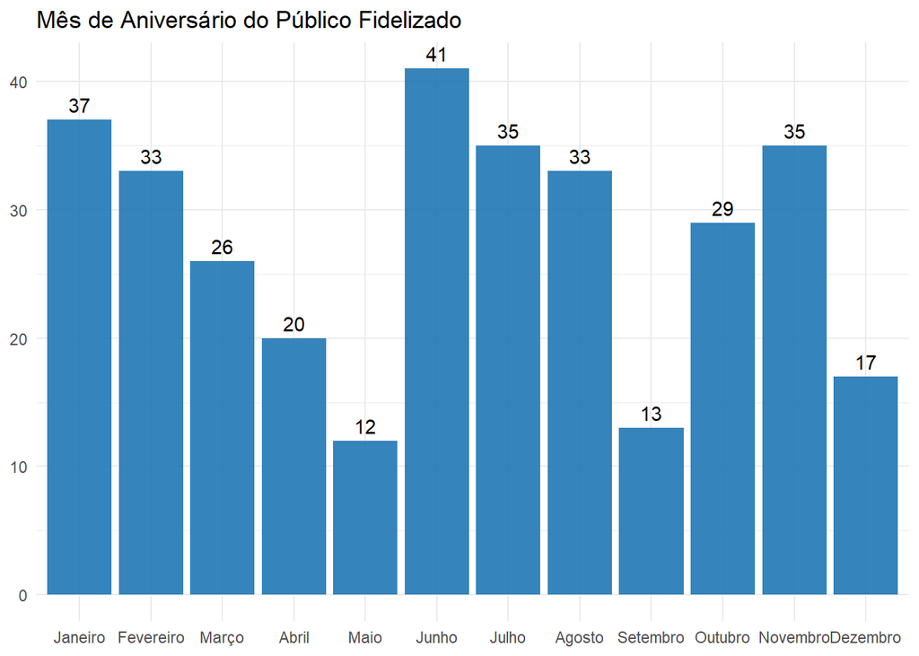

```r
df %>%
  filter(Fidelidade == "Sim") %>%
  group_by(Aniversário) %>%
  summarise("Qtd Clientes" = n()) %>%
  ggplot(aes(Aniversário, `Qtd Clientes`)) +
  geom_col(fill = "#1f77b4", alpha = 0.9) +
  geom_text(aes(label = `Qtd Clientes`), vjust = -0.5) +
  labs(title = "Mês de Aniversário do Público Fidelizado", x=NULL, y=NULL) +
  theme_minimal()
```

O gráfico acima representa a quantidade de aniversários dos clientes fidelizados por mês do ano. É evidente que junho é o mês com o maior número de aniversários de clientes fidelizados, tornando-se uma excelente opção para a realização de campanhas de aniversário direcionadas a esse público.

## 6.4 Percentual de fidelização por região

```r
df %>%
  group_by(Região) %>%
  mutate("Fidelizados" = if_else(Fidelidade == "Sim", 1, NULL)) %>%
  summarise("Qtd Fidelizados" = sum(Fidelizados, na.rm = TRUE),
            "% Fidelização" = (sum(Fidelizados, na.rm = TRUE)/n())*100) %>%
  paged_table()
```

| Região | Qtd Fidelizados | % Fidelização |
| --- | --- | --- |
| Centro-Oeste | 59 | 32.24044 |
| Nordeste | 64 | 31.52709 |
| Norte | 48 | 31.37255 |
| Sudeste | 101 | 33.33333 |
| Sul | 59 | 31.89189 |

A tabela acima possibilita a visualização da quantidade de clientes fidelizados por região, juntamente com o percentual de fidelização em relação ao total de clientes na região. Nota-se que a região Sul possui 31,89% de seus clientes fidelizados, enquanto a região Sudeste apresenta 33,33% de fidelização.

## 6.5 Cinco estados para o lançamento do novo produto

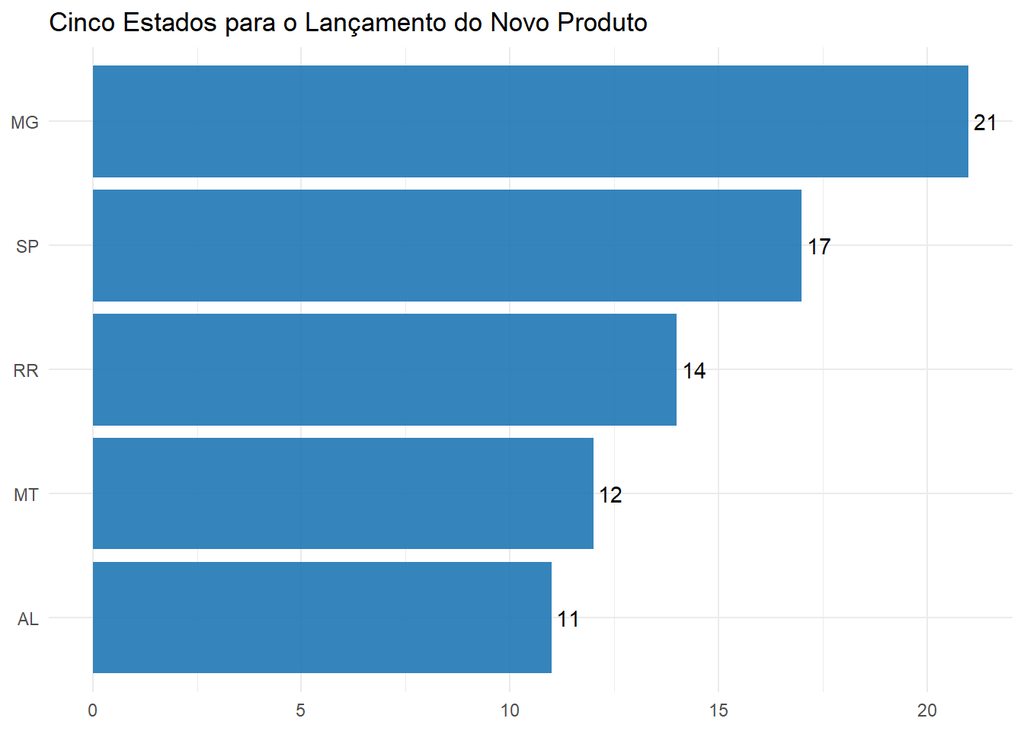

```r
df %>%
  filter(`Nota de consumo` < 45 & Fidelidade == "Sim") %>%
  group_by(UF) %>%
  tally() %>%
  arrange(desc(n)) %>%
  slice(1:5) %>%
  ggplot(aes(reorder(UF, +n), n)) +
  geom_col(fill = "#1f77b4", alpha=0.9)+
  geom_text(aes(label = n), hjust = -0.2) +
  coord_flip() +
  labs(title = "Cinco Estados para o Lançamento do Novo Produto", x=NULL, y=NULL) +
  theme_minimal()
```

O gráfico acima destaca os cinco estados com maior número de clientes fidelizados que possuem uma nota de consumo inferior a 45 pontos. A partir desses dados, pode-se concluir que os estados de Minas Gerais, São Paulo, Roraima, Mato Grosso e Alagoas devem ser selecionados para o lançamento do novo produto direcionado a esse público-alvo.

# 7 Conclusões

Com base nas observações feitas nas etapas anteriores, é possível responder às questões propostas.

**1.** Quais regiões com mais clientes fidelizados?

18. O Sudeste é a região com o maior número de clientes fidelizados, com 101 clientes fidelizados, estando significativamente à frente da maioria das outras regiões.

**3.** Qual melhor mês para fazer uma campanha de aniversário para o público fidelizado?

18. Junho é o melhor mês para realizar uma campanha de aniversário para o público fidelizado, visto que conta com o maior número de clientes fidelizados aniversariantes, totalizando 41.

**4.** Qual percentual de fidelização do público da região Sul e Sudeste?

18. A região geográfica Sul apresenta uma fidelização de 31,89% em relação ao total de seus clientes, enquanto a região Sudeste possui 33,33% de fidelização.

**5**. Queremos lançar um novo produto para o público que possui nota de consumo abaixo de 45, porém são fidelizados. Quais 5 estados devemos selecionar para o lançamento?

18. Minas Gerais, São Paulo, Roraima, Mato Grosso e Alagoas são os estados mais indicados para o lançamento do novo produto, uma vez que apresentam o maior número de clientes fidelizados com nota de consumo inferior a 45 pontos.